# 경돼님분석

doyeon

```r
library(data.table)
library(GGally)
library(lubridate)
library(tidyverse)
library(ggpmisc)
library(recipes)
library(gridExtra)
```

#데이터 불러오기

```r
df_raw <- fread("c:/R/Competition/preprocessing_data.csv",header=T,encoding = 'UTF-8')
df <- df_raw
##데이터 전처리
#1)경돼님이 댓글기능 막으셔서 좋아요 및 싫어요 NA처리 되어서 제거 후 진행.
df <- df %>%
    drop_na()
#2)날짜 및 텍스트 전처리
df <- df %>%
    mutate(published_at = ymd(published_at)) %>%
    mutate(year = year(published_at),
           month = month(published_at),
           wday = wday(published_at,label = T)) %>%
    select(-comments,-tags,-description) %>%
    mutate(interest_rate = (likes+dislikes+comment_count)/view_count,
           total_interest = (likes+dislikes+comment_count)) #**변수추가**
head(df)
```

```
##                                           title published_at published_time
## 1:              100kg 20회 실화?!?? 아이템 착용   2021-05-31             12
## 2:             벤치 120kg,  도와ㅜ줘 도와ㅜ줘!!   2021-05-30             22
## 3:                     출근 전 벤치프레스 100kg   2021-05-26             22
## 4:         궁금했던 것 물어보면 딱 좋은 타이밍!   2021-05-14              2
## 5:       비아냥 속에서도 묵묵히 최선을 다할 것.   2021-04-25              2
## 6: 78kg, 썸머슈레딩(다이어트) 시작, 이건 못참지   2021-03-13             10
##    published_year published_month published_day month_upload_count duration
## 1:           2021               5            31                  4       37
## 2:           2021               5            30                  4       43
## 3:           2021               5            26                  4       42
## 4:           2021               5            14                  4      210
## 5:           2021               4            25                  1       13
## 6:           2021               3            13                  4       31
##    view_count likes dislikes comment_count year month wday interest_rate
## 1:        973    25        2            12 2021     5   월    0.04008222
## 2:       1487    33        0            21 2021     5   일    0.03631473
## 3:       2042    31        3            17 2021     5   수    0.02497551
## 4:       2011    67        2            16 2021     5   금    0.04226753
## 5:       5501   127        7            64 2021     4   일    0.03599346
## 6:       4459   101        1            53 2021     3   토    0.03476116
##    total_interest
## 1:             39
## 2:             54
## 3:             51
## 4:             85
## 5:            198
## 6:            155
```

```r
#변수추가 이유 : likes, dislikes, comment_ct와 view_count의 상관관계가 유의하다.
#따라서 세 변수를 하나로 통합하여 interest라는 변수로 처리하였음
```

#상관관계 분석

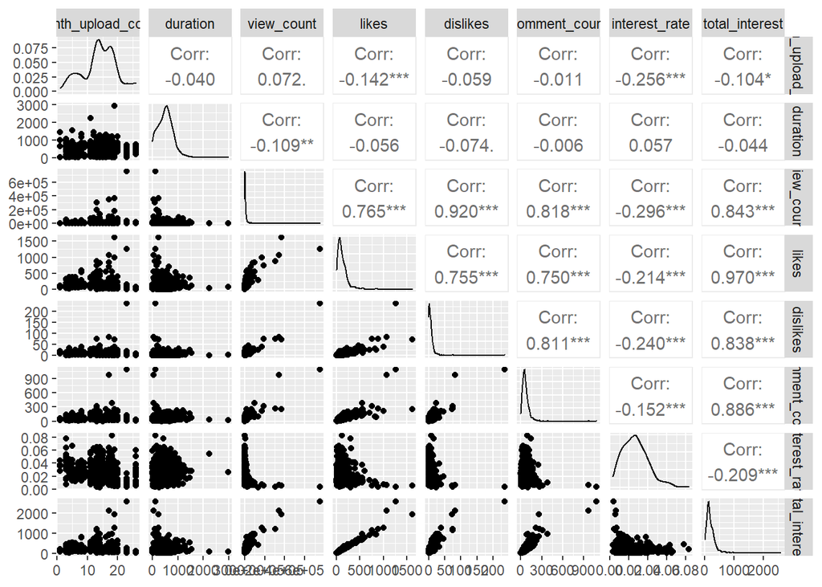

```r
df %>%
    select_if(is.numeric) %>%
    select(-published_time,-published_year,-published_month,-published_day,-year,-month) %>%
    ggpairs()
```

```r
#상관관계 결과 : view_ct와 유의미한 변수는 duration, interest
#주의할 점 : month_upload_ct는 이후 분석을 통해서 중요하다고 생각되나 해당 상관관계비교에선 유의미하지 않다고 나옴. month별로 그룹핑 된 값이기 떄문이라고 판단되어 이후 month별로 그룹핑 후 다시 상관관계 확인 요망.(결론 : 유의미한 변수임.)
```

#분석 진행 방향 : view_ct와 매우 유의한 interest 관련 변수들로 이상치 직접 판단 및 영상 특징 추출/정리  
##HOW? 조회수가 높은 영상들을 interest_rate를 기준으로 알고리즘 등의 외적 요인의 의한 이상치인지 아니면 경돼님에 의한 TOP 영상인지 판단한다.  
##외적 요인의 의한 높은 조회수 영상들을 이상치로 제거하고 조회수 TOP영상들의 특징을 조사해본다. 추출된 특징들로 앞으로 경돼님이 영상을 만드는데 참고할 수 있도록 제시함.  
## + 추가적으로 낮은 조회수 + 낮은 interest의 영상들의 특징도 추출하여 앞으로 지양해야할 특징들을 제시한다.

#분석 전, 월별로 그룹핑하여 upload_ct 변수 중심으로 확인해보기

```r
#월별로 전처리 위한 작업
month_upload_ct <- df %>%
    select(year,month,month_upload_count) %>%
    group_by(year,month) %>%
    summarise(mt_upload_ct = mean(month_upload_count)) %>%
    arrange(year,month) %>%
    select(year,mt_upload_ct)
a <- month_upload_ct[,2]
head(a)
```

```
## # A tibble: 6 x 1
##   mt_upload_ct
##          <dbl>
## 1           13
## 2           26
## 3           23
## 4           20
## 5           19
## 6           13
```

```r
df3 <- df %>%
    select(year,month,view_count,likes,dislikes,comment_count) %>%
    group_by(year,month) %>%
    summarise(mean_month_view = mean(view_count),
              mt_total_interest = sum(likes+dislikes+comment_count),
              mt_interest_rate = mean((likes+dislikes+comment_count)/view_count),
              total_view = sum(view_count)) %>%
    arrange(year,month) %>%
    bind_cols(a) %>%
    mutate(date = paste(year,month) %>% ym)
head(df3)
```

```
## # A tibble: 6 x 8
## # Groups:   year [1]
##    year month mean_month_view mt_total_interest mt_interest_rate total_view
##   <dbl> <dbl>           <dbl>             <dbl>            <dbl>      <int>
## 1  2016     5           3278.               608           0.0214      42612
## 2  2016     6           2940.              1004           0.0252      76432
## 3  2016     7          40857.              4048           0.0111     939709
## 4  2016     8          16686.              2825           0.0154     333726
## 5  2016     9          35934.              4917           0.0168     682738
## 6  2016    10           6606.              1510           0.0259      85875
## # ... with 2 more variables: mt_upload_ct <dbl>, date <date>
```

#월별로 변환한 변수들 상관관계 확인

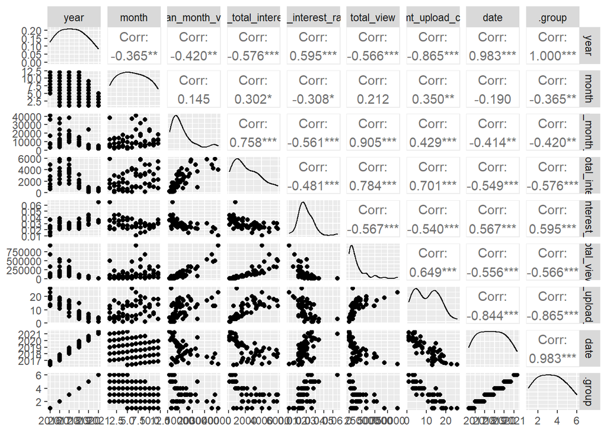

```r
df3 %>% ggpairs()
```

```r
#분석 결과 - upload_ct는 중요한 변수이다.
#cor.test 진행
#1)view_ct & upload_count 상관관계 유의미함.
cor.test(df3$mean_month_view,df3$mt_upload_ct) #0.4291062 /  p-value = 0.0007765
```

```
##
##  Pearson's product-moment correlation
##
## data:  df3$mean_month_view and df3$mt_upload_ct
## t = 3.5551, df = 56, p-value = 0.0007765
## alternative hypothesis: true correlation is not equal to 0
## 95 percent confidence interval:
##  0.1921023 0.6188148
## sample estimates:
##       cor
## 0.4291062
```

```r
#2)total_interest,month_upload_count 상관관계 유의미함
cor.test(df3$mt_total_interest,df3$mt_upload_ct) #0.7014436 / p-value = 8.632e-10
```

```
##
##  Pearson's product-moment correlation
##
## data:  df3$mt_total_interest and df3$mt_upload_ct
## t = 7.3649, df = 56, p-value = 8.632e-10
## alternative hypothesis: true correlation is not equal to 0
## 95 percent confidence interval:
##  0.5412029 0.8125260
## sample estimates:
##       cor
## 0.7014436
```

```r
#3)view_ct & total_interest 상관관계 유의미함.
cor.test(df3$mean_month_view,df3$mt_total_interest) #0.7575452 /p-value = 5.863e-12
```

```
##
##  Pearson's product-moment correlation
##
## data:  df3$mean_month_view and df3$mt_total_interest
## t = 8.6843, df = 56, p-value = 5.863e-12
## alternative hypothesis: true correlation is not equal to 0
## 95 percent confidence interval:
##  0.6207028 0.8495993
## sample estimates:
##       cor
## 0.7575452
```

```r
#4)total_interest & interest_rate 상관관계 유의미함.
cor.test(df3$mt_total_interest,df3$mt_interest_rate)#-0.4810885 / p-value = 0.000132
```

```
##
##  Pearson's product-moment correlation
##
## data:  df3$mt_total_interest and df3$mt_interest_rate
## t = -4.1066, df = 56, p-value = 0.000132
## alternative hypothesis: true correlation is not equal to 0
## 95 percent confidence interval:
##  -0.6576612 -0.2544060
## sample estimates:
##        cor
## -0.4810885
```

```r
#5)interest_rate  & view_ct 상관관계 유의미함.
cor.test(df3$mt_interest_rate,df3$mean_month_view)#-0.5614843  / p-value = 4.531e-06
```

```
##
##  Pearson's product-moment correlation
##
## data:  df3$mt_interest_rate and df3$mean_month_view
## t = -5.0777, df = 56, p-value = 4.531e-06
## alternative hypothesis: true correlation is not equal to 0
## 95 percent confidence interval:
##  -0.7159470 -0.3546186
## sample estimates:
##        cor
## -0.5614843
```

#연도별 평균 view / interest_rate 구하기

```r
#연도별 평균 view, 평균 interest_rate, 총 흥미도 구하기
df %>%
    select(year,month,view_count,likes,dislikes,comment_count) %>%
    filter(year != 2016) %>%
    group_by(year) %>%
    summarise(yr_mean_view = mean(view_count),
              yr_interest_rate = mean((likes+dislikes+comment_count)/view_count),
              yr_total_interest = sum(likes+dislikes+comment_count))
```

```
## # A tibble: 5 x 4
##    year yr_mean_view yr_interest_rate yr_total_interest
##   <dbl>        <dbl>            <dbl>             <dbl>
## 1  2017       15155.           0.0282             38980
## 2  2018       16365.           0.0258             45268
## 3  2019        8860.           0.0281             17843
## 4  2020        6709            0.0371              4850
## 5  2021        3249.           0.0408              2057
```

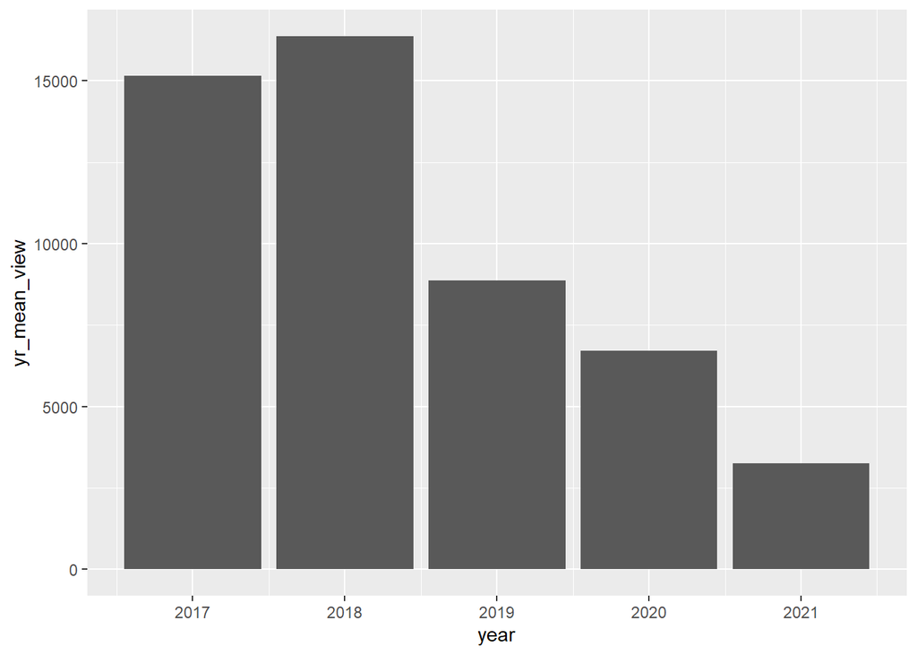

```r
#년평균 view 시각화
df %>%
    select(year,month,view_count,likes,dislikes,comment_count) %>%
    filter(year != 2016) %>%
    group_by(year) %>%
    summarise(yr_mean_view = mean(view_count),
              yr_interest_rate = mean((likes+dislikes+comment_count)/view_count)) %>%
    arrange(year) %>%
    ggplot(aes(year,yr_mean_view))+
    geom_bar(stat = 'identity')
```

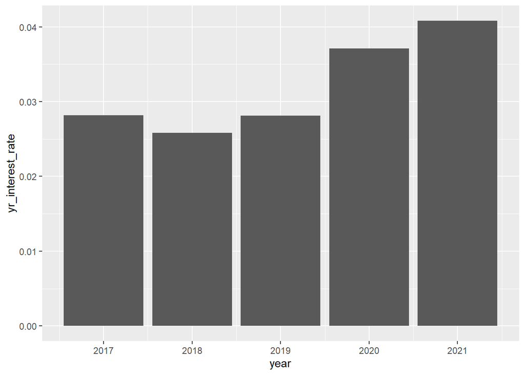

```r
#년 평균 흥미도 시각화
df %>%
    select(year,month,view_count,likes,dislikes,comment_count) %>%
    filter(year != 2016) %>%
    group_by(year) %>%
    summarise(yr_mean_view = mean(view_count),
              yr_interest_rate = mean((likes+dislikes+comment_count)/view_count),
              yr_total_interest = sum(likes+dislikes+comment_count)) %>%
    arrange(year) %>%
    ggplot(aes(year,yr_interest_rate))+
    geom_bar(stat = 'identity')
```

#년도별 데이터 시각화 - 이상치 직접 확인하기

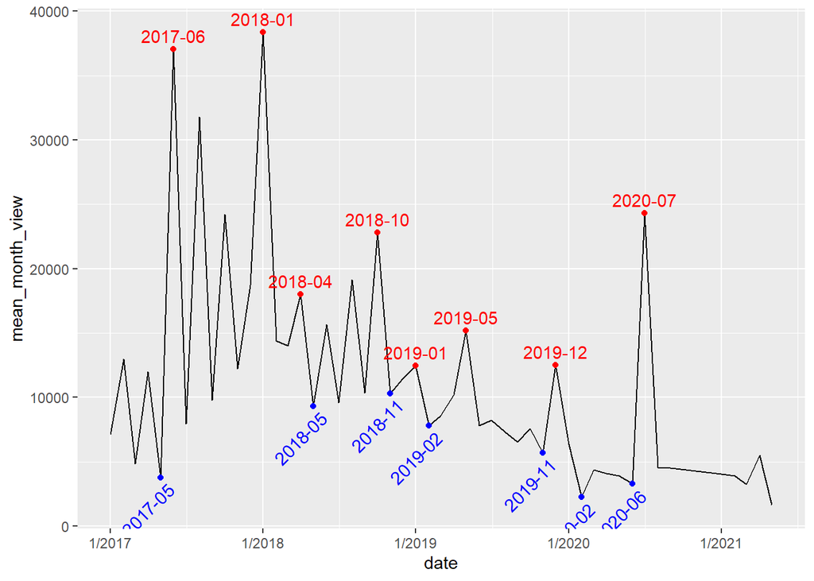

```r
df3 %>%
    mutate(date = paste(year,month) %>% ym) %>%
    filter(year != 2016) %>%
    select(date,everything()) %>%
    ggplot(aes(date,mean_month_view))+
    geom_line()+
    scale_x_date(date_labels = "%b/%Y")+
    stat_peaks(colour = "red") + #극대점 빨간점으로 표시
    stat_peaks(geom = "text", colour = "red", #극대점 날짜("%Y-%m") 표시
               vjust = -0.5, x.label.fmt = "%Y-%m") +
    stat_valleys(colour = "blue") +  #극소점 파란점으로 표시
    stat_valleys(geom = "text", colour = "blue", angle = 45,
                 vjust = 1.5, hjust = 1,  x.label.fmt = "%Y-%m")
```